# UNICEF Data Story

Author

Tushar Goradia (Student ID: A00047860)

Published

April 24, 2024

# UNICEF Data Story: Exploring Global Trends in Child Welfare and Aging Populations: A Data-Driven Approach Using UNICEF Indicators

**Module:** BAA1030 Data Analytics & Story Telling  
**Module Code:** 20074  
**Programme:** MSc in Management (Strategy)

**Student ID:** A00047860

## Introduction

Global health trends have shown remarkable progress in recent decades, yet deep inequalities remain. In this report, we focus on two critical areas: child vaccination rates and old-age dependency, examining how countries, particularly India, are navigating these demographic challenges.

```python
!pip install pandas plotnine geopandas
```

```python
import matplotlib.pyplot as plt
```

```python
import pandas as pd
from plotnine import *
import geopandas as gpd

indicator1 = pd.read_csv('/content/drive/MyDrive/unicef_indicator_1.csv')
indicator2 = pd.read_csv('/content/drive/MyDrive/unicef_indicator_2.csv')
metadata = pd.read_csv('/content/drive/MyDrive/unicef_metadata.csv')
```

### Vaccination Rate Over Time in India

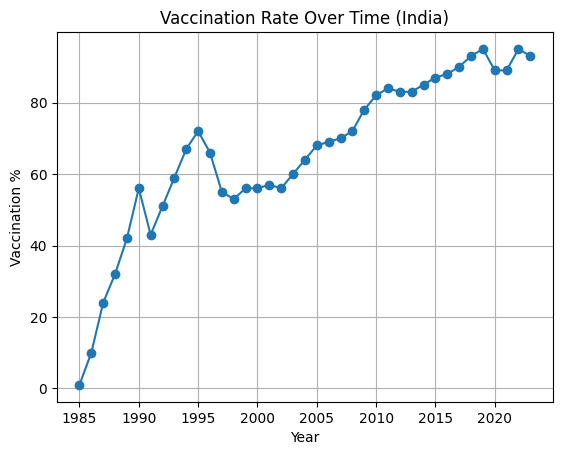

```python
import matplotlib.pyplot as plt
import pandas as pd

indicator2 = pd.read_csv('/content/drive/MyDrive/unicef_indicator_2.csv')
india_data = indicator2[indicator2['country'] == 'India']

plt.plot(india_data['time_period'], india_data['obs_value'], marker='o')

plt.title('Vaccination Rate Over Time (India)')
plt.xlabel('Year')
plt.ylabel('Vaccination %')
plt.grid(True)

plt.show()
```

### GDP per Capita vs Life Expectancy in India

Next, we explore the relationship between economic prosperity and life expectancy. The GDP per Capita vs Life Expectancy scatterplot clearly shows that as India’s wealth grew, life expectancy also rose — although gaps remain compared to more developed nations.

This scatter plot explores the relationship between India’s GDP per capita and life expectancy over time. A linear trendline shows how improvements in economic conditions have correlated with increases in life expectancy.

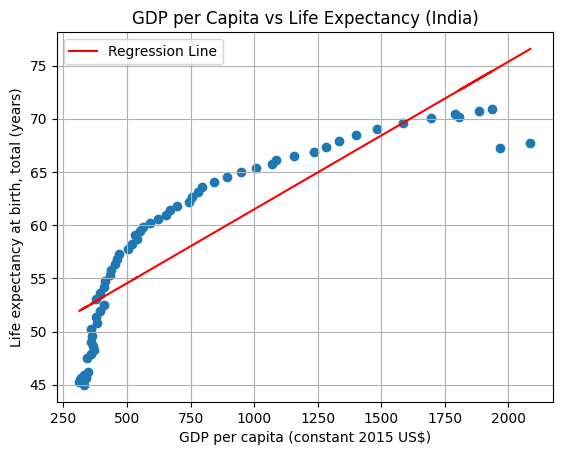

```python
import matplotlib.pyplot as plt
import pandas as pd
import numpy as np


india_data = metadata[metadata['country'] == 'India'].dropna(subset=['GDP per capita (constant 2015 US$)', 'Life expectancy at birth, total (years)'])

x = india_data['GDP per capita (constant 2015 US$)']
y = india_data['Life expectancy at birth, total (years)']

slope, intercept = np.polyfit(x, y, 1)

reg_line = slope * x + intercept

plt.scatter(x, y)

plt.plot(x, reg_line, color='red', label='Regression Line')

plt.title('GDP per Capita vs Life Expectancy (India)')
plt.xlabel('GDP per capita (constant 2015 US$)')
plt.ylabel('Life expectancy at birth, total (years)')
plt.grid(True)
plt.legend()

plt.show()
```

### Old Age Dependency Ratio in India Since 2000 (by Gender)

As populations live longer, a new concern emerges: aging societies. The Old Age Dependency Ratio in India grouped bar chart highlights how the burden of supporting elderly citizens has increased steadily since 2000 — across both genders. This demographic shift brings significant economic and social implications for the future.

This grouped bar chart displays how India’s old-age dependency ratio has evolved since 2000, separately for males, females, and the total population. It highlights changing gender patterns as the population ages.

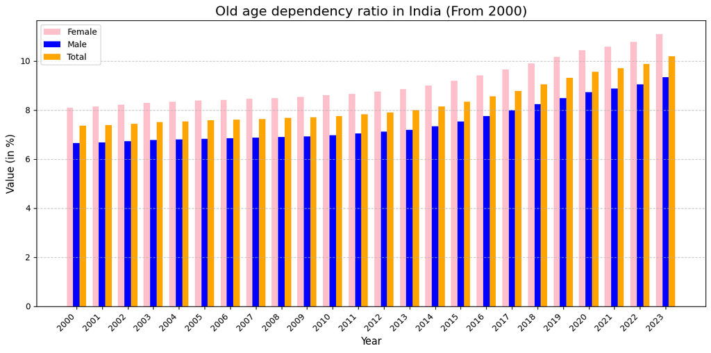

```python
import matplotlib.pyplot as plt
import pandas as pd
import numpy as np

indicator_name = 'Old age dependency ratio'
india_data = indicator1[
    (indicator1['indicator'] == indicator_name) &
    (indicator1['country'] == 'India') &
    (indicator1['time_period'] >= 2000)
]


grouped_data = india_data.groupby(['time_period', 'sex'])['obs_value'].mean().reset_index()


plt.figure(figsize=(12, 6))
width = 0.25
years = grouped_data['time_period'].unique()
sexes = grouped_data['sex'].unique()

plt.bar(years - width, grouped_data[grouped_data['sex'] == 'Female']['obs_value'], width, label='Female', color='pink')
plt.bar(years, grouped_data[grouped_data['sex'] == 'Male']['obs_value'], width, label='Male', color='blue')
plt.bar(years + width, grouped_data[grouped_data['sex'] == 'Total']['obs_value'], width, label='Total', color='orange')

plt.title(f'{indicator_name} in India (From 2000)', fontsize=16)
plt.xlabel('Year', fontsize=12)
plt.ylabel('Value (in %)', fontsize=12)
plt.xticks(years, years, rotation=45, ha='right', fontsize=10)
plt.legend(fontsize=10)
plt.grid(True, axis='y', linestyle='--', alpha=0.7)
plt.tight_layout()
plt.show()
```

### Global Old Age Dependency Ratio

Zooming out to the global scale, the Old Age Dependency Ratio World Globe shows that aging populations are not just a local issue. Countries like Japan, Italy, and Germany face the highest old-age dependency burdens, demanding urgent reforms in pensions, healthcare, and workforce planning.

This interactive globe visualizes old-age dependency ratios across countries. Darker red shades indicate higher elderly dependency relative to the working-age population, highlighting regions most affected by aging trends.

```python
import plotly.io as pio

pio.renderers.default = 'notebook_connected'
```

```python
import plotly.graph_objects as go
import pandas as pd


indicator_name = 'Old age dependency ratio'
indicator_data = indicator1[indicator1['indicator'] == indicator_name]

latest_dependency_rates = indicator_data.groupby('country')['obs_value'].last().reset_index()

fig = go.Figure(data=go.Choropleth(
    locations=latest_dependency_rates['country'],
    z=latest_dependency_rates['obs_value'],
    locationmode='country names',
    colorscale='Reds',
    colorbar_title="Dependency Ratio",
))

fig.update_layout(
    title_text='Global Old Age Dependency Ratio',
    geo=dict(
        showframe=False,
        showcoastlines=False,
        projection_type='orthographic'
    )
)

fig.show()
```

[interactive chart not shown]

### Latest Vaccination Rates Worldwide

Finally, we turn again to child health. The Latest Vaccination Rates World Map starkly highlights that many countries — especially in Africa and parts of Asia — still struggle to provide basic vaccinations. While global averages improve, millions of children remain vulnerable due to unequal access to healthcare.

This interactive world map displays the most recent child vaccination rates across countries. The visualization highlights global inequalities in healthcare access and immunization coverage.

```python
import plotly.express as px
import pandas as pd
```

```python
indicator2 = pd.read_csv('/content/drive/MyDrive/unicef_indicator_2.csv')
```

```python
import plotly.graph_objects as go
import pandas as pd

latest_vaccination_rates = indicator2.groupby('country')['obs_value'].last().reset_index()

fig = go.Figure(data=go.Choropleth(
    locations=latest_vaccination_rates['country'],
    z=latest_vaccination_rates['obs_value'],
    locationmode='country names',
    colorscale='Viridis',
    colorbar_title="Vaccination Rate",
))

fig.update_layout(
    title_text='Latest Vaccination Rates by Country',
    geo=dict(
        showframe=False,
        showcoastlines=False,
        projection_type='equirectangular'
    )
)

fig.show()
```

[interactive chart not shown]

Through this journey, the data tells a powerful story: As countries work to protect their youngest citizens, they must also prepare to care for their oldest. Balancing these priorities will define the next generation of global health and social policy.

## Conclusion

Our global visualizations further emphasize these dual pressures. While vaccination coverage has expanded in many parts of the world, significant disparities remain, particularly in low-income regions. Simultaneously, developed nations are contending with rising old-age dependency ratios, reshaping social, economic, and healthcare priorities.

Addressing these challenges will require a balanced approach: investing in both child health and elderly care, while recognizing the underlying economic factors that influence health outcomes. The future of public health will depend not only on curing disease but on building resilient, inclusive systems that serve populations across every stage of life.

## Data Sources

The data used in this report is sourced from UNICEF global indicators datasets provided for the BAA1030 Data Storytelling assignment. Additional metadata was used to enhance the demographic analysis.

```python
import plotly.io as pio
pio.renderers.default = 'notebook'
```